化學計量學 · 近紅外光譜 · 機器學習教學

# 🥚 用近紅外光譜 (NIR) + PLS 迴歸 預測雞蛋的儲存天數

Python & Orange Data Mining 雙工具實作教材

**對應論文：**Coronel-Reyes, J., Ramirez-Morales, I., Fernandez-Blanco, E., Rivero, D., & Pazos, A. (2018). *Determination of egg storage time at room temperature using a low-cost NIR spectrometer and machine learning techniques.* *Computers and Electronics in Agriculture*, 145, 1–10. [doi:10.1016/j.compag.2017.12.030](https://doi.org/10.1016/j.compag.2017.12.030)  
**資料集：**[Mendeley Data — 6hn67h2trb (v2)](https://data.mendeley.com/datasets/6hn67h2trb/2) dataset_egg_storage.csv

660 筆樣本30 顆褐殼蛋 第 0–21 天740–1070 nm · 331 波長 SCiO 手持式光譜儀

## 🎯學習目標

完成本教材後，你將能夠：

1. 說明**近紅外光譜 (NIR)** 為何能非破壞性地反映雞蛋的老化。
2. 對光譜資料做 **SNV、Savitzky–Golay 微分**等前處理，並理解每種方法的目的。
3. 用 **PLS 迴歸**處理「特徵多又高度相關」的光譜資料，並用**交叉驗證**挑選潛在變數數量。
4. 用 **R²、RMSE、RMSECV** 評估迴歸模型，並判讀「預測 vs 實際」圖。
5. 辨識**資料洩漏**：理解「隨機分折」與「依樣本分組」驗證的差異。
6. 分別用 **Python（程式）** 與 **Orange Data Mining（視覺化拖拉）** 完成同一個分析。

🧰 下載本教材的檔案

[▶ 在 Google Colab 開啟筆記本](https://colab.research.google.com/github/Tai-ShengYeh/Tai-ShengYeh.github.io/blob/main/nir-egg-freshness/PLS_egg_freshness_colab.ipynb)  
📄 dataset_egg_storage.csv（原始資料） 📓 PLS_egg_freshness_colab.ipynb（Python/Colab） 🍊 egg_storage_orange.tab（Orange 資料） 🍊 egg_pls_orange.ows（Orange 工作流程） 🐍 run_analysis.py（繪圖腳本）

## 1為什麼要測雞蛋的新鮮度？

雞蛋從產下那一刻就開始老化：蛋白變稀、氣室變大、蛋白 pH 因二氧化碳逸散而上升、蛋殼外層的**角質層 (cuticle)**逐漸乾燥變薄。 傳統評估新鮮度的**哈夫單位 (Haugh Unit)** 雖然準確，卻是**破壞性**的（必須打破蛋來量濃蛋白高度），無法用在產線上逐顆檢測。

論文指出：在室溫 (23±1°C) 下，雞蛋大約可存放 **14 天**；之後品質明顯下降。 因此若能用一支接在**智慧型手機**上的**低成本光譜儀**，**不打破蛋**就估出「這顆蛋放了幾天」，對產業與消費者都極具價值。 這正是本研究與本教材要解決的問題：**用光譜迴歸出儲存天數 `storage_days`**。

💡 這是一個「迴歸」問題

目標變數 `storage_days` 是連續數值（0、1、2 … 21 天），所以我們用**迴歸**（PLS Regression）而非分類。 輸入則是每顆蛋的一條近紅外光譜。

## 2近紅外光譜原理 & 蛋的化學變化

**近紅外光 (NIR, 約 700–2500 nm)** 照到樣品時，會激發分子中 **C–H、O–H、N–H** 等化學鍵的**倍頻 (overtone)** 與 **合頻 (combination)** 振動。不同化學組成 → 不同的吸收/反射特徵，因此光譜等於樣品的「化學指紋」。

本研究使用的 **SCiO 手持式光譜儀**波長範圍 **740–1070 nm**，屬於「短波近紅外」。在這個波段：

- **~890 nm**：C–H 第三倍頻
- **~960 nm**：O–H 第二倍頻（與水/角質層含水量有關）
- **~1020 nm**：N–H 第二倍頻（與蛋白質有關）

光在 700–900 nm 可穿透約 **3–4 mm**，足以穿過蛋殼抵達**角質層與蛋白**（但到不了蛋黃）。 隨著儲存時間增加，角質層乾燥變薄、蛋殼碳酸鈣礦物更外露、CH/OH/NH 化學鍵改變 —— 這些都會反映在光譜上， 讓模型「看得出」蛋的年紀。

📷 量測方式

每顆蛋從**鈍端 (blunt end)** 量測、套上遮光配件以隔絕外界光，並把兩次重複量測**平均**成一筆資料。

## 3認識資料集

研究團隊監測 **30 顆褐殼蛋**（H&N 品系、49–52 週齡母雞、蛋重 55–65 g）， 從產下當天 (第 0 天) 起連續 **22 天**、每天量一次，得到 **30 × 22 = 660 筆**光譜。

| 欄位 | 意義 | 在建模中的角色 |
| --- | --- | --- |
| `storage_days` | 已儲存天數 0–21 | **目標 y**（要預測的值） |
| `sample` | 蛋的編號 1–30（同一顆蛋出現 22 次） | 分組驗證用（見第 8 節） |
| `Spectra_740` … `Spectra_1070` | 各波長的反射率（331 個） | **特徵 X** |

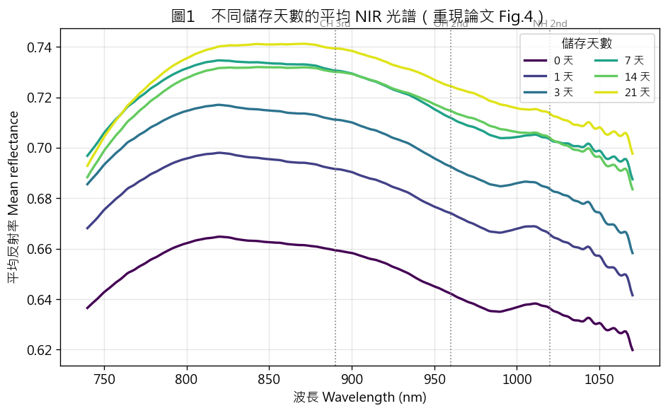

## 4PLS 迴歸是什麼？為什麼適合光譜？

我們有 **331 個波長（特徵）**，但它們有兩個棘手特性：

- **高度共線性**：相鄰波長的反射率幾乎一模一樣（高度相關）。
- **特徵多**：波長數量可能比樣本數還多。

普通最小平方法 (OLS) 在這種情況會因矩陣不可逆而崩潰。**PLS（偏最小平方, Partial Least Squares）**的巧思是：

💡 PLS 的核心想法

不直接用 331 個波長，而是找出少數幾個**潛在變數 (Latent Variables, LV)**。 每個 LV 都是波長的線性組合，並且被刻意挑選成**「同時解釋 X 的變異、又和 y（天數）最相關」**的方向。 於是把 331 維壓縮成大約 10 維，還保留了最能預測天數的資訊。

與只看 X 自身變異的 PCA 不同，PLS 是**監督式**的 —— 它在降維時就「偷看」了 y。 最關鍵的超參數就是 **要用幾個 LV**：太少會**欠擬合**，太多會**過擬合**。我們用交叉驗證來決定（第 7 節）。

## 5光譜前處理 (Preprocessing)

原始光譜混有與化學無關的干擾 —— 蛋殼粗糙造成的**散射**、儀器或擺放造成的**基線漂移**。 前處理的目的就是去除這些干擾、突顯化學訊號。常見方法：

| 方法 | 做什麼 | 解決什麼 |
| --- | --- | --- |
| **SNV** Standard Normal Variate | 每條光譜各自減平均、除標準差 | 散射造成的乘性/加性偏移 |
| **Savitzky–Golay 平滑** | 在小窗內用多項式擬合再取值 | 隨機雜訊（降噪） |
| **一階微分 (1st derivative)** | 取相鄰點的斜率 | 固定基線偏移 |
| **二階微分 (2nd derivative)** | 取斜率的變化率 | 線性基線；突顯吸收峰（但放大雜訊） |

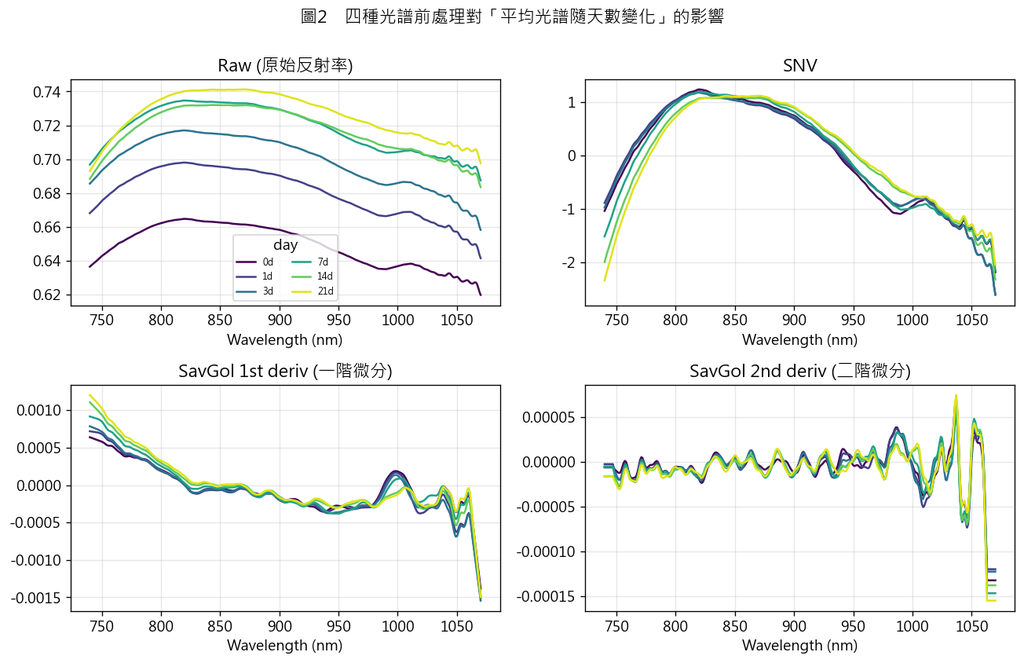

## 6Python 建模流程

以下是用 `scikit-learn` 的核心程式碼（完整、可一鍵執行的版本在第 12 節的 Colab 筆記本）。

### ① 載入資料、切出 X / y

```
import numpy as np, pandas as pd
from scipy.signal import savgol_filter
from sklearn.cross_decomposition import PLSRegression
from sklearn.model_selection import cross_val_predict, KFold, GroupKFold
from sklearn.metrics import r2_score, mean_squared_error

df = pd.read_csv("dataset_egg_storage.csv")
Xcols = [c for c in df.columns if c.startswith("Spectra_")]
X = df[Xcols].values                 # (660, 331) 光譜
y = df["storage_days"].values        # 目標：天數
groups = df["sample"].values          # 蛋編號（分組驗證用）
```

### ② 定義前處理

```
def snv(s):
    return (s - s.mean(axis=1, keepdims=True)) / s.std(axis=1, keepdims=True)

def sg(s, deriv=2, window=15, poly=2):   # Savitzky-Golay 微分
    return savgol_filter(s, window_length=window, polyorder=poly, deriv=deriv, axis=1)

Xp = sg(X, deriv=2)                   # 本例最佳：二階微分
```

### ③ 訓練 PLS 並用交叉驗證評估

```
kf = KFold(n_splits=10, shuffle=True, random_state=42)
yhat = cross_val_predict(PLSRegression(n_components=12, scale=True), Xp, y, cv=kf)

rmse = np.sqrt(mean_squared_error(y, yhat))
print(f"R² = {r2_score(y, yhat):.3f}　RMSECV = {rmse:.2f} 天")
# -> R² = 0.820　RMSECV = 2.69 天
```

🔧 為什麼要 `scale=True`？

PLS 對特徵尺度敏感。`scale=True` 會在建模前把每個波長標準化（StandardScaler）， 避免數值大的波長主導模型。這等同論文流程中的「mean-center / autoscale」步驟。

## 7選潛在變數數量：一倍標準誤法則

「要用幾個 LV」是 PLS 最重要的決定。作法是對每個候選數量跑 10-fold 交叉驗證， 算出 **RMSECV**（交叉驗證均方根誤差），畫成曲線。

RMSECV = √( Σ (y<sub>i</sub> − ŷ<sub>i</sub>)² / n ) （單位：天，越小越好）

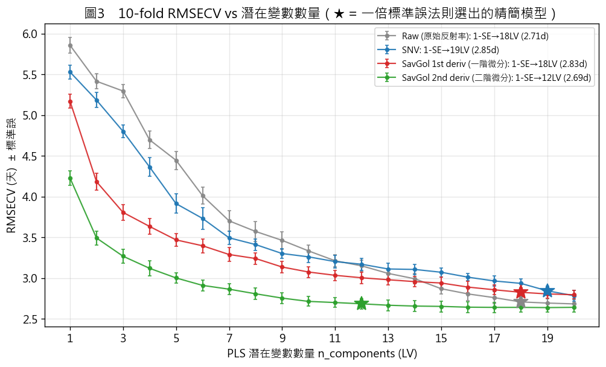

圖 3 四種前處理下 RMSECV 隨 LV 數量變化（誤差棒為 ±1 標準誤）。 **SavGol 二階微分（綠線）用最少的 LV 就達到最低誤差**，因此雀屏中選。

⚠️ 不要直接抓最低點！

曲線在 LV 很多時往往還在緩緩下降，直接取最低點常選到約 19–20 個 LV，**有過擬合風險**。

💡 一倍標準誤法則 (One-Standard-Error Rule)

在「最低 RMSECV ＋ 1 個標準誤」的範圍內，選**最少的 LV**。這樣得到的模型更精簡、更穩健， 且和最佳值在統計上沒有顯著差異。本例 → **SavGol 二階微分 + 12 個 LV**。

## 8⚠️ 驗證的陷阱：隨機分折 vs 依「蛋」分組

這是整份教材**最重要的觀念**。回想資料結構：同一顆蛋被量了 22 次（第 0 天到第 21 天）。 同一顆蛋第 5 天和第 6 天的光譜長得非常像。

如果用**隨機** 10-fold，這兩筆很可能一筆落在訓練集、一筆落在驗證集。模型可能靠「**認得這顆蛋**」 來壓低誤差，而不是真的學會「判斷天數」。這種因資料切分不當而高估表現的現象，叫做**資料洩漏 (data leakage)**。

💡 解法：GroupKFold（依蛋分組）

把同一顆蛋的全部 22 筆資料**整組**放進同一折，模擬「預測一顆從沒見過的新蛋」。 這才是誠實的泛化能力評估。

```
# 依蛋編號分組做交叉驗證
gkf = GroupKFold(n_splits=10)
yhat_grp = cross_val_predict(PLSRegression(n_components=12, scale=True),
                             Xp, y, cv=gkf, groups=groups)
```

| 驗證方式 | R² | RMSECV (天) | MAE (天) |
| --- | --- | --- | --- |
| 隨機 10-fold CV | 0.820 | 2.69 | 2.18 |
| **依蛋分組 GroupKFold** | 0.811 | 2.75 | 2.22 |

✅ 本例的好消息

兩者差距非常小（R² 只掉 0.009）。這代表模型主要學到的是**「老化的化學變化」而非「某顆蛋的身分」**， 對全新的蛋一樣有效，泛化能力良好。**但你必須親手驗證過，才能這樣說。**

## 9結果與解讀

0.82

R²（決定係數）

2.69

RMSECV（天）

2.18

MAE 平均絕對誤差（天）

12

潛在變數 (LV)

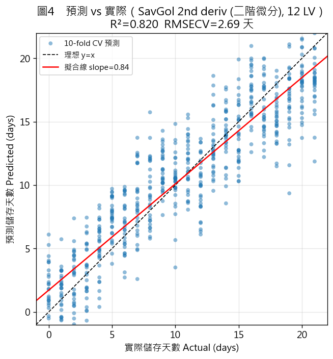

圖 4 預測 vs 實際（重現論文 Fig. 9a）。點越靠近對角線越好。

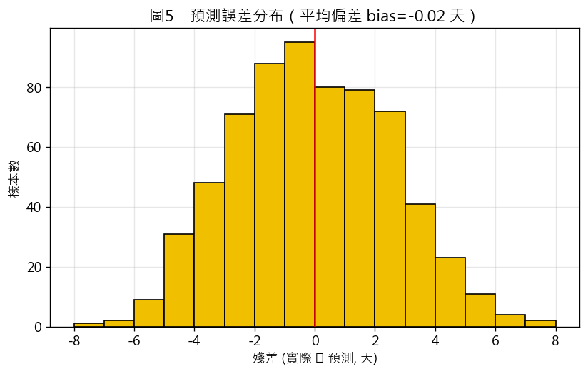

圖 5 預測誤差分布（重現論文 Fig. 9b），大致對稱、集中在 0 附近。

模型可在 ±2.7 天的誤差內估出雞蛋年紀。**圖 4 的擬合線斜率略小於 1**（約 0.84），代表 PLS 常見的 **向均值收縮**：很新鮮(接近 0 天)的蛋會被略微高估、很舊(接近 21 天)的蛋會被略微低估。

📊 和論文比較

論文用**類神經網路 (ANN)** 取得最佳結果 R²=0.832、RMSECV=1.97 天；其 PLS 模型 R² 略低於 0.80。 我們這個教學版 PLS（二階微分 + 12 LV）達到 R²≈0.82，與論文同等級，且用更精簡、更易解釋的線性模型 —— 非常適合教學。

## 10哪些波長最重要？（VIP 與迴歸係數）

建好模型後，我們想知道它「看了光譜的哪些位置」。**VIP (Variable Importance in Projection)** 衡量每個波長對 PLS 的貢獻，慣例以 **VIP > 1** 視為重要波長。

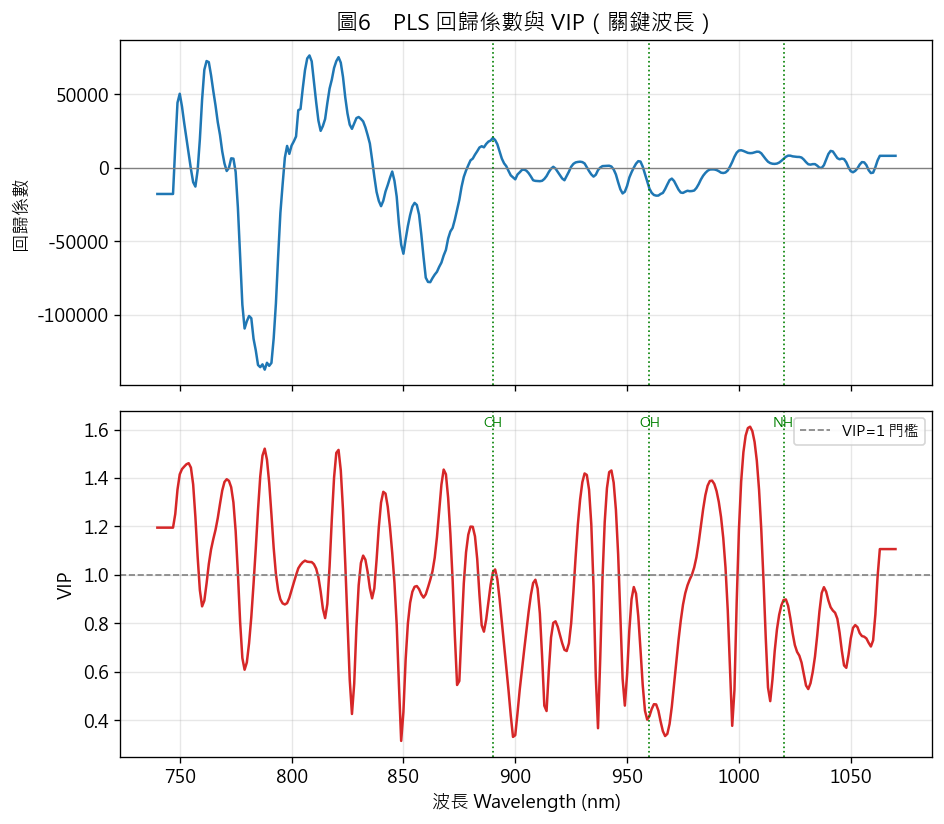

圖 6 上：PLS 迴歸係數；下：VIP 分數（綠色虛線為化學鍵位置）。 最重要的波長集中在 **~1000 nm（N–H/O–H 區）** 與 **~790–820 nm（C–H 區）**。

本例 VIP 最高的波長約為 **788、821、1002–1007 nm**。這與論文觀察一致：蛋在儲存過程中， 角質層含水量與蛋白質的 N–H/O–H 鍵結改變，使得 ~1000 nm 附近成為判斷天數的關鍵區域。 **模型不是黑盒子 —— 它的依據可以對應到真實的化學變化。**

### PCA 探索（補充）

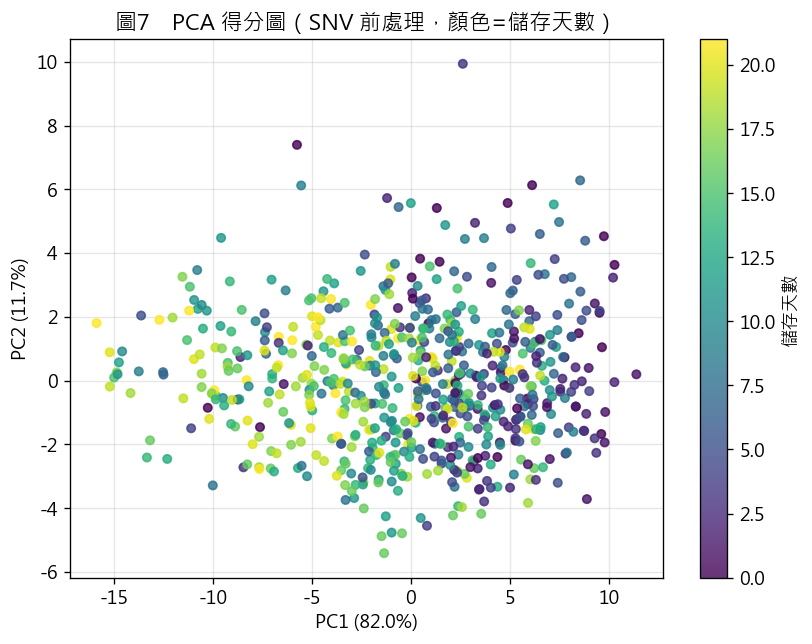

圖 7 PCA 得分圖（SNV 前處理）。前兩個主成分就解釋約 **94%** 的變異， 且顏色（天數）沿著 PC1 呈現漸層 —— 顯示「老化」是資料中最主要的變異來源。

## 11用 Orange Data Mining 實作（不寫程式）

[Orange Data Mining](https://orangedatamining.com/) 是一套**視覺化拖拉**的資料分析軟體， 特別適合不熟程式的學生：把「元件 (widget)」拉到畫布上、用線連起來，就完成分析。

⚠️ 先安裝光譜外掛

SNV / Savitzky–Golay 等光譜前處理需要 **Spectroscopy 外掛**（即 Quasar）。 安裝路徑：Orange 選單 `Options → Add-ons…` → 勾選 **Spectroscopy** → 安裝後重啟。

### 步驟：建立工作流程

1

**File**：載入 egg_storage_orange.tab。 此檔已標好欄位角色（`storage_days`=target、`sample`=meta、其餘為光譜特徵），開檔即可用。

2

**Data Table**：接在 File 後面，檢視資料是否正確載入。

4

**PLS**：把 *Components* 設為 **12**。

5

**Test and Score**：接收 Preprocess 的資料 (Data) 與 PLS 的 Learner， 選 **Cross validation, 10 folds**。即可在表格看到 R²、RMSE、MAE。

6

**Predictions → Scatter Plot**：把預測值對實際 `storage_days` 畫散佈圖，重現圖 4。

🔗 連線方式（資料流）

`File → Data Table`；`File → Preprocess Spectra`； `Preprocess Spectra → PLS`；`Preprocess Spectra → Test and Score`（Data）； `PLS → Test and Score`（Learner）； `Preprocess Spectra → Predictions`、`PLS → Predictions`；`Predictions → Scatter Plot`。

✅ 直接打開現成工作流程

本教材附的 egg_pls_orange.ows 已把上述七個元件接好。用 Orange 開啟後： ① 點 File 重新指定到你電腦上的 `egg_storage_orange.tab`； ② 在 Preprocess Spectra 內加入 SNV 與 SavGol（.ows 提供骨架，前處理步驟請依步驟 3 自行加入）； ③ 確認 PLS components=12、Test and Score 選 10-fold。

💡 進階：用 Orange 重現「依蛋分組」驗證

在 Test and Score 中，若資料含一個 meta 欄位 `sample`，可改用 **Cross validation by feature**（依特徵分組）並選 `sample`，即等同 Python 的 GroupKFold —— 對照第 8 節。

## 12用 Google Colab 跑 Python（免安裝）

**Google Colab** 是免費的雲端 Python 環境，學生只要有 Google 帳號、用瀏覽器即可執行，無需安裝任何東西。

### 開啟方式（任選一種）

A

**一鍵開啟（推薦）**：直接點下方按鈕，會用 Colab 開啟本教材的筆記本。

B

**直接上傳**：到 colab.research.google.com → 選單 `檔案 → 上傳筆記本` → 選你下載的 PLS_egg_freshness_colab.ipynb。

筆記本第一個資料格會跳出**上傳視窗**，請選擇 `dataset_egg_storage.csv`（可從本頁上方「下載」區或 Mendeley 連結取得）， 接著由上到下逐格執行 (`Shift+Enter`) 即可。

[▶ 在 Google Colab 開啟筆記本](https://colab.research.google.com/github/Tai-ShengYeh/Tai-ShengYeh.github.io/blob/main/nir-egg-freshness/PLS_egg_freshness_colab.ipynb) ⬇ 下載資料 CSV

🈶 關於圖表文字

Colab 預設沒有中文字型，故筆記本內**圖表座標軸用英文**以免顯示方框；所有教學解說都寫在中文文字格中。 本教學 HTML 的圖（圖 1–7）則已用中文字型繪製。

## 13Python vs Orange：兩種工具怎麼選？

| 面向 | Python (scikit-learn) | Orange Data Mining |
| --- | --- | --- |
| 操作方式 | 寫程式碼 | 拖拉元件、連線 |
| 學習曲線 | 較陡（需懂語法） | 平緩（視覺化、即時預覽） |
| 彈性 / 客製 | 極高（任何流程、自訂函式） | 受限於現有元件 |
| 可重現 / 自動化 | 強（腳本、版本控制） | 適合互動探索 |
| 適合對象 | 需要客製分析、寫論文 | 教學入門、快速試驗、概念理解 |

💡 建議的教學順序

先用 **Orange** 拖拉一遍，建立「資料 → 前處理 → 模型 → 驗證」的整體直覺； 再用 **Python** 把同一流程寫出來，理解每一步的細節並學會客製。兩者結果應一致 —— 這也是很好的交叉驗證！

## 14動手練習

1. **換前處理**：把二階微分改成 SNV 或原始光譜，重跑第 6 節，比較 RMSECV 差多少。
2. **改 LV 數量**：手動設成 2、5、19 個 LV，觀察圖 4 與過/欠擬合現象。
3. **窗寬實驗**：改 Savitzky–Golay 的 `window`（如 7、25），看二階微分的雜訊如何變化。
4. **改成分類題**：依「室溫最多放 14 天」，把問題改成「新鮮 (≤7 天) vs 不新鮮 (>7 天)」二元分類， 用 PLS-DA 或邏輯迴歸做做看。
5. **波長篩選**：只用 VIP > 1 的波長重建模型，準確度會變好還是變差？對應論文的「波長選擇」步驟。
6. **雙工具對照**：用 Orange 跑出 R²/RMSE，和 Python 的結果比對，思考為何可能有小差異（亂數種子、分折方式）。

## 📚參考資料與檔案清單

### 論文與資料

- Coronel-Reyes, J. *et al.* (2018). Determination of egg storage time at room temperature using a low-cost NIR spectrometer and machine learning techniques. *Computers and Electronics in Agriculture*, 145, 1–10. [doi:10.1016/j.compag.2017.12.030](https://doi.org/10.1016/j.compag.2017.12.030)
- 資料集：[Mendeley Data — 6hn67h2trb (v2)](https://data.mendeley.com/datasets/6hn67h2trb/2)
- Wold, S. *et al.* (2001). PLS-regression: a basic tool of chemometrics. *Chemometrics Intell. Lab. Syst.*

### 本教材附帶檔案（點擊下載）

- dataset_egg_storage.csv — 原始資料（Python / Colab 用）
- PLS_egg_freshness_colab.ipynb — Python 教學筆記本（Google Colab）
- egg_storage_orange.tab — Orange 專用資料（已標欄位角色，波長欄位為純數字）
- egg_pls_orange.ows — Orange 工作流程（七元件已接好）
- run_analysis.py — 產生本頁所有圖的完整 Python 腳本

### 工具

- Python：[scikit-learn](https://scikit-learn.org/)、 [Google Colab](https://colab.research.google.com)
- [Orange Data Mining](https://orangedatamining.com/) + [Spectroscopy (Quasar) 外掛](https://quasar.codes/)